# Red Wine Quality Data Analysis by Paul Hsiao

```
## Source: local data frame [6 x 6]
##
##   quality Min Median      Mean  Max   n
## 1       3 8.4  9.925  9.955000 11.0  10
## 2       4 9.0 10.000 10.265094 13.1  53
## 3       5 8.5  9.700  9.899706 14.9 681
## 4       6 8.4 10.500 10.629519 14.0 638
## 5       7 9.2 11.500 11.465913 14.0 199
## 6       8 9.8 12.150 12.094444 14.0  18
```

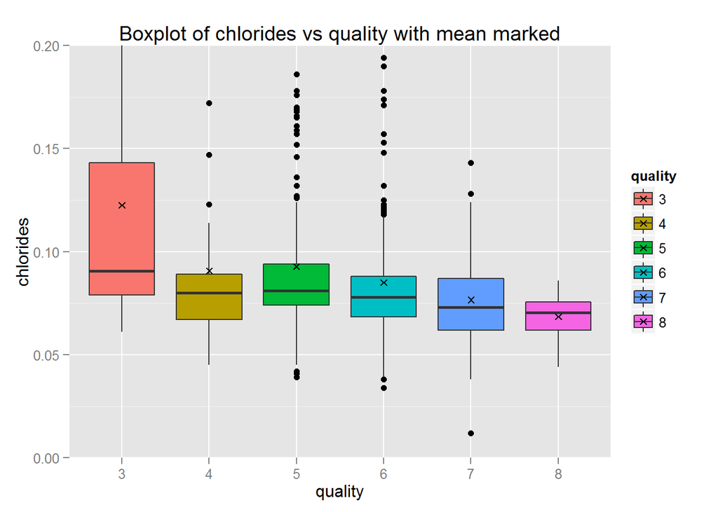

```
## Source: local data frame [6 x 6]
##
##   quality   Min Median       Mean   Max   n
## 1       3 0.061 0.0905 0.12250000 0.267  10
## 2       4 0.045 0.0800 0.09067925 0.610  53
## 3       5 0.039 0.0810 0.09273568 0.611 681
## 4       6 0.034 0.0780 0.08495611 0.415 638
## 5       7 0.012 0.0730 0.07658794 0.358 199
## 6       8 0.044 0.0705 0.06844444 0.086  18
```

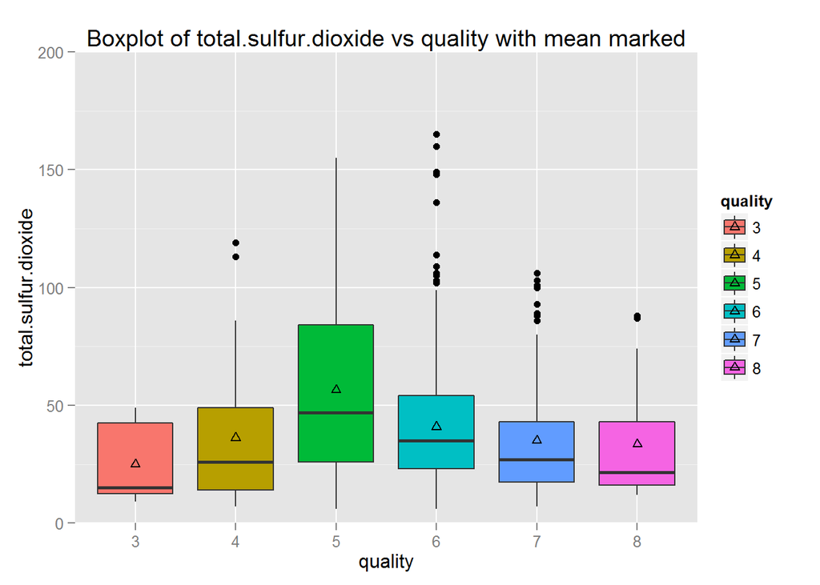

```
## Source: local data frame [6 x 6]
##
##   quality Min Median     Mean Max   n
## 1       3   9   15.0 24.90000  49  10
## 2       4   7   26.0 36.24528 119  53
## 3       5   6   47.0 56.51395 155 681
## 4       6   6   35.0 40.86991 165 638
## 5       7   7   27.0 35.02010 289 199
## 6       8  12   21.5 33.44444  88  18
```

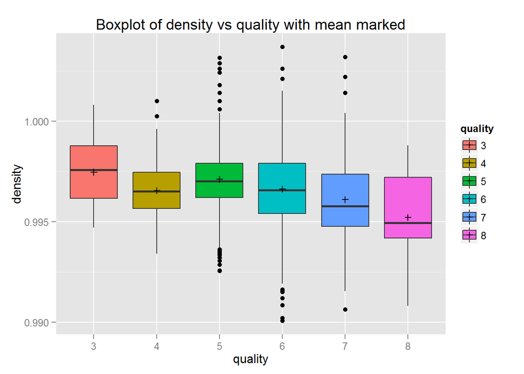

```
## Source: local data frame [6 x 6]
##
##   quality     Min   Median      Mean     Max   n
## 1       3 0.99471 0.997565 0.9974640 1.00080  10
## 2       4 0.99340 0.996500 0.9965425 1.00100  53
## 3       5 0.99256 0.997000 0.9971036 1.00315 681
## 4       6 0.99007 0.996560 0.9966151 1.00369 638
## 5       7 0.99064 0.995770 0.9961043 1.00320 199
## 6       8 0.99080 0.994940 0.9952122 0.99880  18
```

These boxplots show some interesting information for the wine with high rating quality. They demonstrates the distribution of the focused features per quality. The following are observed for the quality 8 wines:

1. Low pH value (median: 3.23)
2. Low residual sugar (median: 2.1)
3. High alcohol (median: 12.15)
4. Low chlorides (median: 0.0705)
5. Low total.sulfur.dioxide (median: 21.5)
6. Low density (median: 0.994940)

# Bivariate Analysis

### Talk about some of the relationships you observed in this part of the investigation. How did the feature(s) of interest vary with other features in the dataset?

From the Scatterplot matrices, the following are observed:

1. fixed.acidity and density have positive Correlation Coefficient of 0.668.
2. fixed.acidity and pH have negative Correlation Coefficient -0.683. This is expected as higher acidity will decrease the pH value.
3. The rest of the correlations are weak. None of the features has high correlation with quality directly.
4. The scatterplots with smoother have reinforced the above observations.

### Did you observe any interesting relationships between the other features (not the main feature(s) of interest)?

free.sulfur.dioxide and total.sulfur.dioxide have a positive Correlation Coefficient of 0.668. However, this is not a surprise as free.sulfur.dioxide is included in total.sulfur.dioxide.

### What was the strongest relationship you found?

fixed.acidity and pH have the highest Correlation Coefficient -0.683. Wine makers can adjust the pH level, ie. fixed acidity level, so their wine can satisfy consumer’s taste. In this dataset, the median pH level is 3.310.

# Multivariate Plots Section

## 1. pH vs median alcohol per quality

First, lets have a look of pH vs median alcohol per quality.

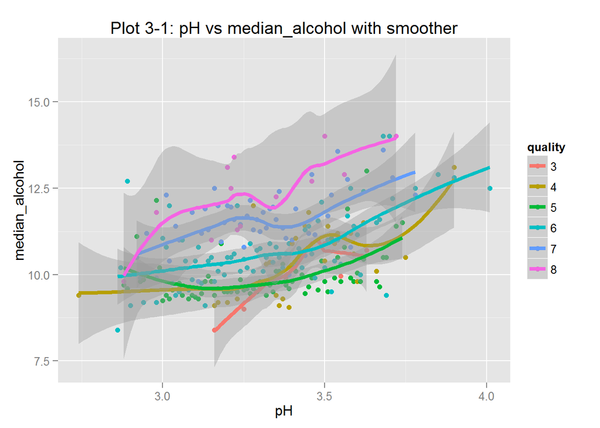

```
## [1] "The correlation between median_alcohol and pH is 0.385979783696859"
```

This plot shows the pH has a positive correlation with median alcohol value for each quality. For higher quality wines, the median alcohol tends to have higher value for the same pH value. This plot gives better details into each quality than the following plot which shows the smooth trend across all qualities of wine.

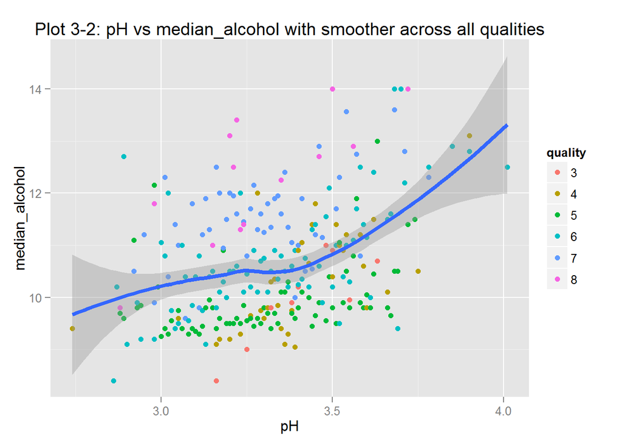

## 2. alcohol vs density per pH bucket

Next, lets look at the alcohol vs density per pH bucket.

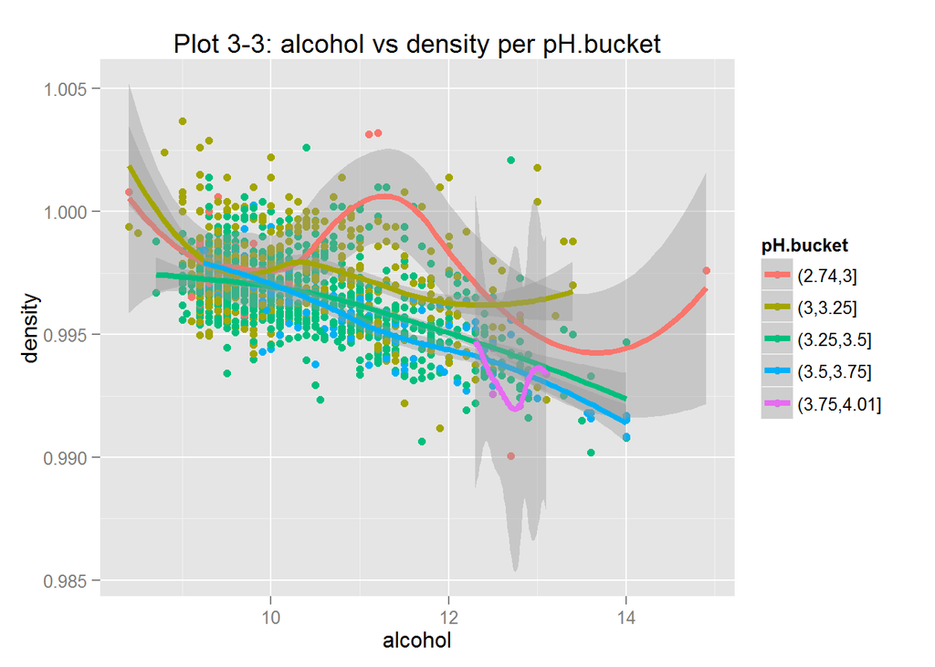

```
## [1] "The correlation between alcohol and density is -0.496179770241702"
```

```
## Source: local data frame [5 x 6]
##
##     pH.bucket     Min  Median      Mean     Max   n
## 1    (2.74,3] 0.99007 0.99760 0.9978503 1.00320  34
## 2    (3,3.25] 0.99120 0.99733 0.9974518 1.00369 515
## 3  (3.25,3.5] 0.99020 0.99647 0.9964985 1.00260 881
## 4  (3.5,3.75] 0.99084 0.99588 0.9957486 1.00025 161
## 5 (3.75,4.01] 0.99210 0.99320 0.9932871 0.99471   7
```

And here is the distribution of alcohol per pH.bucket:

```
## Source: local data frame [5 x 6]
##
##     pH.bucket       Min Median     Mean  Max   n
## 1    (2.74,3]  8.400000   9.85 10.27647 14.9  34
## 2    (3,3.25]  8.400000  10.00 10.26667 13.4 515
## 3  (3.25,3.5]  8.700000  10.20 10.40904 14.0 881
## 4  (3.5,3.75]  9.233333  10.80 10.93944 14.0 161
## 5 (3.75,4.01] 12.300000  12.50 12.65714 13.1   7
```

Now, I’ll show the plot with top 1% alcohol and density removed from the dataset, plus jitter and alpha=0.5.

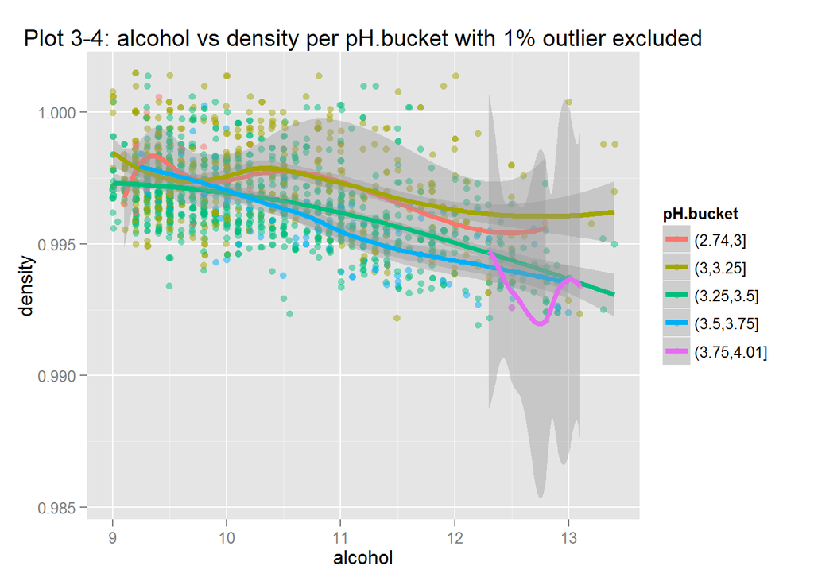

```
## [1] "The correlation between alcohol and density is -0.483549367718379"
```

This plot looks much better compared with previous plot. The trend for all pH.buckets are obvious, except the pH.bucket 3.75-4.01. This is due to pH.bucket 3.75-4.01 has small number of sample data. In general, the alcohol has a negative correlation with density.

## 3. Build a model

Now, lets try to build a model to show some statistical measures.

```
##
## Calls:
## m1: lm(formula = I(quality) ~ I(pH), data = reddf)
## m2: lm(formula = I(quality) ~ I(pH) + density, data = reddf)
## m3: lm(formula = I(quality) ~ I(pH) + density + fixed.acidity, data = reddf)
## m4: lm(formula = I(quality) ~ I(pH) + density + fixed.acidity + alcohol,
##     data = reddf)
## m5: lm(formula = I(quality) ~ I(pH) + density + fixed.acidity + alcohol +
##     residual.sugar, data = reddf)
##
## ===========================================================================
##                     m1          m2          m3          m4          m5
## ---------------------------------------------------------------------------
## (Intercept)       6.636***  101.930***   213.196***  29.491      24.579
##                  (0.433)    (11.256)     (13.348)   (17.324)    (21.430)
## I(pH)            -0.302*     -0.696***     0.824***  -0.419*     -0.443*
##                  (0.131)     (0.136)      (0.169)    (0.178)     (0.189)
## density                     -94.297***  -213.161*** -26.811     -21.802
##                             (11.130)     (13.595)   (17.610)    (21.807)
## fixed.acidity                              0.262***   0.065**     0.061*
##                                           (0.019)    (0.022)     (0.025)
## alcohol                                               0.356***    0.361***
##                                                      (0.023)     (0.027)
## residual.sugar                                                   -0.006
##                                                                  (0.015)
## ---------------------------------------------------------------------------
## R-squared            0.003       0.046       0.148       0.257       0.257
## adj. R-squared       0.003       0.045       0.146       0.255       0.255
## sigma                0.806       0.789       0.746       0.697       0.697
## F                    5.340      38.678      92.403     137.741     110.165
## p                    0.021       0.000       0.000       0.000       0.000
## Log-likelihood   -1923.965   -1888.793   -1798.518   -1689.282   -1689.205
## Deviance          1038.692     993.987     887.857     774.470     774.396
## AIC               3853.930    3785.586    3607.036    3390.563    3392.411
## BIC               3870.062    3807.095    3633.922    3422.826    3430.051
## N                 1599        1599        1599        1599        1599
## ===========================================================================
```

The result from this linear model seems indicate the fixed.acidity and alcohol have more impact to the quality figure than other feature in the model.

# Multivariate Analysis

### Talk about some of the relationships you observed in this part of the investigation. Were there features that strengthened each other in terms of looking at your feature(s) of interest?

From plot 3-1 and 3-2, it is observed the pH and median_alcohol has positive correlation. Higher quality wines have higher median_alcohol value. So, the pH and alcohol are strengthened each other in this analysis.

From plot 3-4, it shows the alcohol and density has negative correlation.

### OPTIONAL: Did you create any models with your dataset? Discuss the strengths and limitations of your model.

Yes, I did create a model. The strength is it has low p value. However, the R-squared is quite low.

# Final Plots and Summary

## Plot One

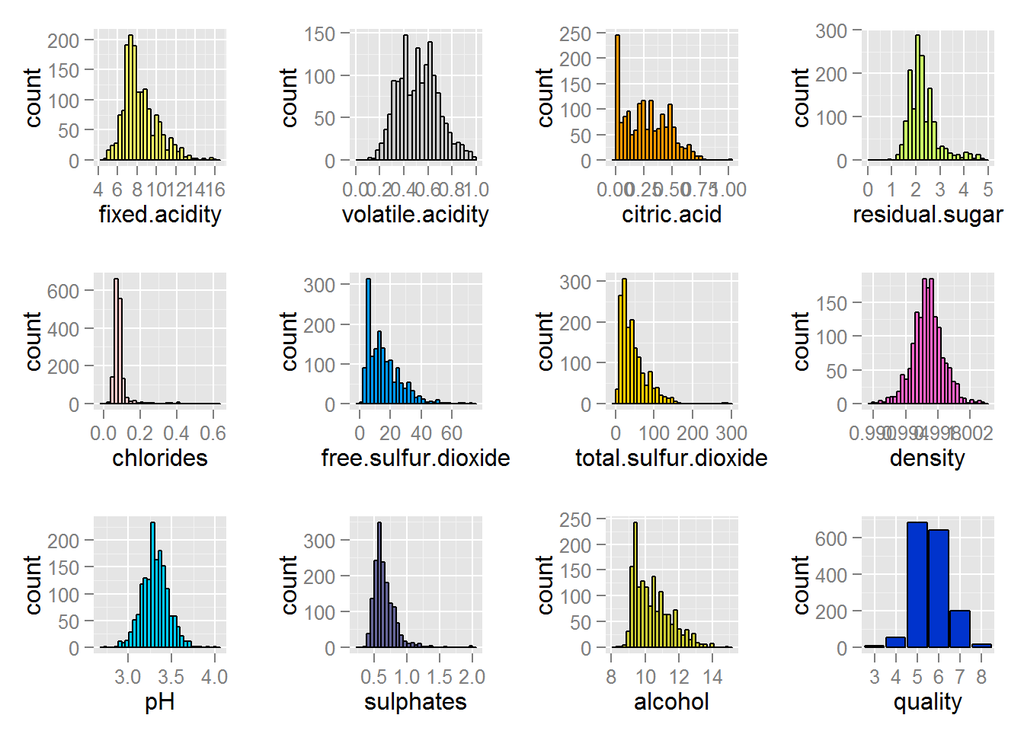

## Description One

This is the grid of histograms of all features. It show the distribution of each feature in the dataset. It provides the general idea about the dataset variable distribution before we looking into correlation between features.

## Plot Two

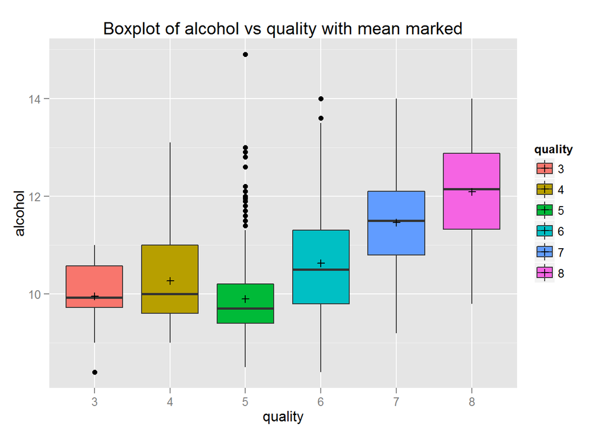

## Description Two

This plot clearly demonstrates the relationship between alcohol and quality. Even though the quality depends on other features as well, the plot shows the higher alcohol level is correlated to higher quality value in general.

## Plot Three

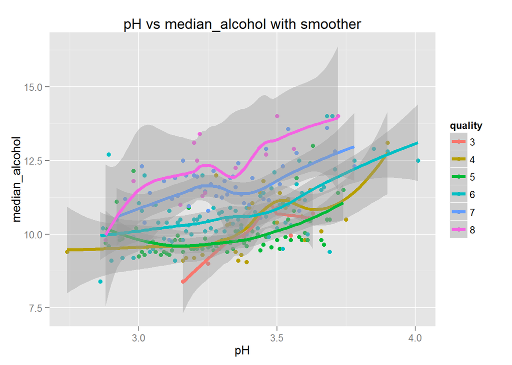

## Description Three

This plot shows the pH vs median_alcohol trend -  
1. For the same pH level, higher median_alcohol level linked to higher quality value.  
2. For the same median_alcohol level, lower pH level leads to higher quality value.

# Reflection

It is a interesting subject to explore using the Data Analysis we learnt in this course. Without knowing much about the relationship between features, it was a bit hard to pick the features of interest in the begining. However, once I went through the Univariate, bivariate and multivariate ploting involving different feature combinations, the picture is getting clear. Even though there is no definite conclusion from the analysis, a few key observations did provide us a good picture for the relationship of quality and interested features. There are still a lot of plotting technics we have not applied during the course yet. Even though the dataset provides only limited features in red wine, I believe with further exploring using more plotting technics, we can be more certain about the relationship between quality and features.